As I commented in a [previous post](https://geovanjr.github.io/2020-06-19-A-function-for-easy-assessment-of-variables-normality/), I am an R beginner with beginner needs. In that post I presented a function (`whos_norm`) that evaluates the normality of a set of variables on a data, based on Shapiro-Wilk test. Now, I will show you a function, somewhat complementary to `whos_norm`, called `transf`, that applies a transformation on a chosen variable and evaluates its normality after the transformation.

I know transformation may be a *baby thing* for some people, but sometimes it is not for who is starting. Actually, the interesting in using `transf` is the time saving.

The `transf` function allows for several transformations, including $log$ ($log_{2},~log_{10},~log_{e}$), z-score, square and cube roots, square, inverse and arcsine of the square root.

So, assuming a variable $\mathbf{x}$, what `transf` actually does is:

- For $log$-transform, it calculates $log_{b}(x)$, where $b$ can be either $2$, $10$ or $e$ (i.e., $ln(x)$).
- For square root transformation, it calculates $\sqrt{x}$, while for cube root, $\sqrt[3]{x}$.
- For square transforming, just $x^2$.
- For inverse transformation, $\frac{1}{x}$.
- Finally, for centering, it just subtracts the mean of $\mathbf{x}$ ($\mu$) for each of its value, $x_i-\mu$. To standardize instead of centering, it just divides the centered $\mathbf{x}$ by its standard deviation ($\sigma$), scaling to z-score: $(x_i-\mu)/\sigma$.

This said, we again will use the `iris` dataset for illustrate the function usage. Recalling the previous post, we saw that 3 variables from this data were not normally distributed:

```r
whos_norm(iris)$not_normal
```

| variable | W | p | signif |
| --- | --- | --- | --- |
| Sepal.Length | 0.976 | 0.0102 | * |
| Petal.Length | 0.876 | 0.0000 | * |
| Petal.Width | 0.902 | 0.0000 | * |

Let’s apply a log-transformation on `Sepal.Length` using `transf`. At first, obviously, you have to load the function:

```r
source("https://github.com/geovanjr/stats/raw/master/transf.R")
```

If you check the function, you will notice that it has 4 arguments: `transf(x, trans, data, plot)`.

- In the `x` argument you have to specify the variable you want to transform, exactly how it is named on your dataset.
- In the `trans` argument, you will specify the transformation type as a string/character. It allows for `'log'` ($ln$), `'log2'`, `'log10'` (logarithm transformation), `'sqrt'` for square root, `'cuberoot'` for cubic root, `'sq'` for square, `'inverse'` for inverse, `'center'` for centering and `'z-score'` for z-score.
- In the `data` argument, the dataset must be specified (`tibble` or `data.frame`).
- The `plot` argument is logical and optional. By default, a two Q-Q plot (one of the raw value and another of the variable transformed) with the corresponding Shapiro-Wilk statistics evaluation is ploted after running the function. You can set `plot` to `FALSE` if you do not want it to print. Even if you choose not to print it, the plot will be saved and can be assessed anytime.

All right, now let’s transform `Sepal.Length`.

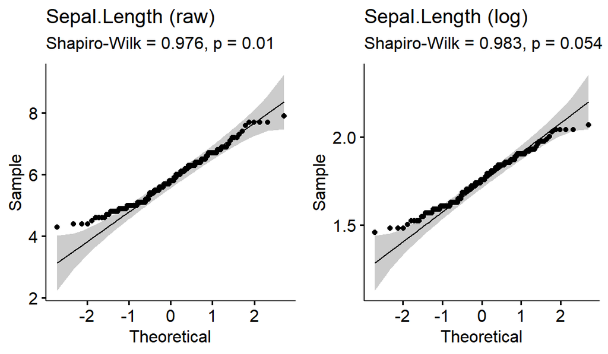

```r
transf(x = Sepal.Length, trans = 'log', data = iris)
```

So, we can see that the log-transforming `Sepal.Length` makes its Shapiro-Wilk p-value jump to 0.054.

If we look to the density plot before and after transformation (I standardized the curves dividing by the sum to make it fall in a same scale and turns it easy to compare):

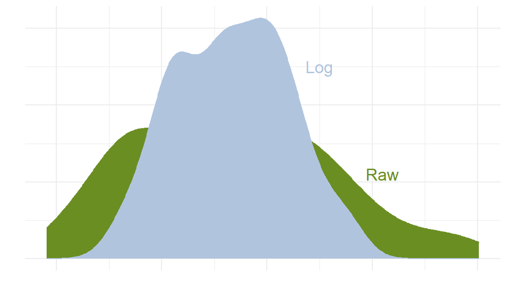

we realize that although the log-curve is not a perfect sine, it is nearer to a gaussian shape than the raw curve.

If you want a silent evaluation, just set plot to `FALSE` and save the output into an object, as follows:

```r
sl_transf <- transf(Sepal.Length, 'log', iris, plot = F)
```

`sl_transf` is a list comprised of 6 elements:

```r
names(sl_transf)
```

```
## [1] "x"          "W"          "p"          "plot_raw"   "plot_trans"
## [6] "plot_grid"
```

Where `x` is the value of the transformed variable, `W` and `p` refers to the `shapiro.test`, `plot_raw` is the Q-Q plot of the untransformed `x`, `plot_trans` is the Q-Q plot of `x` after transformation and `plot_grid` is a grid containing both raw and transformed Q-Q plots. We can assess any of these elements with the dollar sign ($\$$).

Maybe you want to save the transformed values on your dataset:

```r
iris_Sepal.Length_log <- sl_transf$x
```

Or see the Q-Q plots:

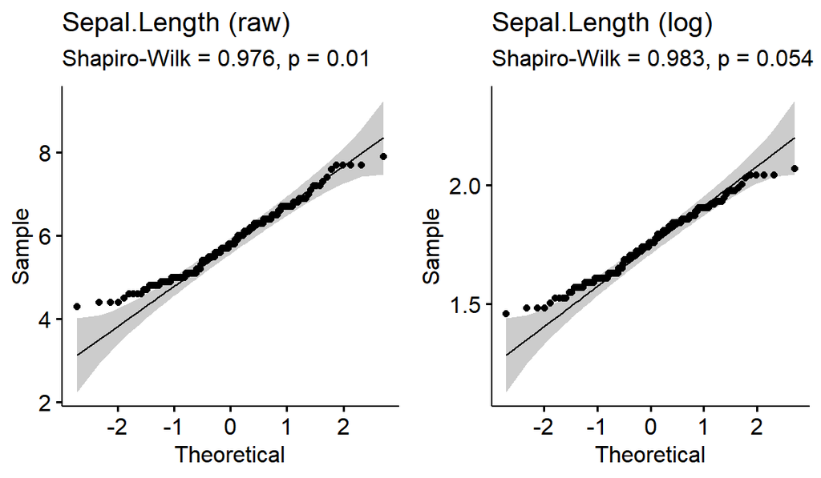

```r
sl_transf$plot_grid
```

You can also apply the function to a subset of the data anytime:

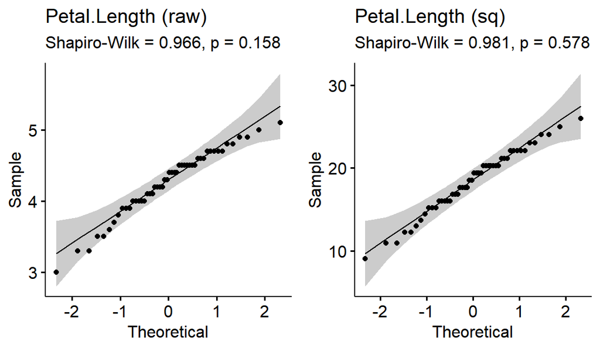

```r
transf(Petal.Length, 'sq', iris %>% subset(Species == 'versicolor'))
```

To use the function with a vector already saved in your Global Environment, just omit the `data` argument.

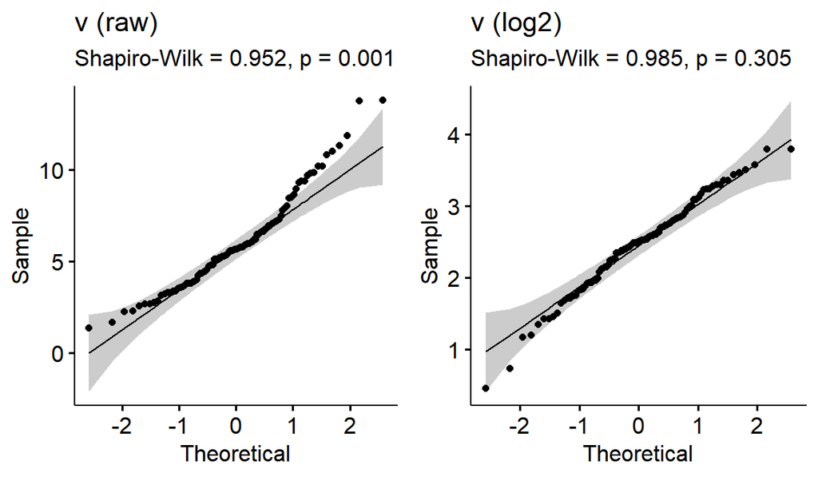

```r
v <- rgamma(100,6)

transf(v, 'log2')
```

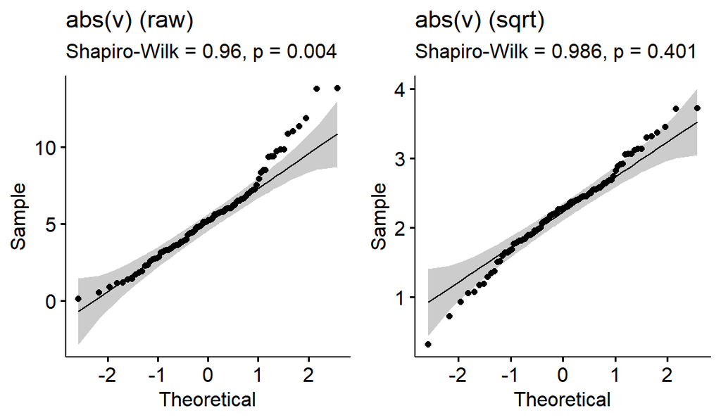

```r
v[25:40] <- rnorm(length(25:40))*5

transf(abs(v), 'sqrt')
```

#### Some considerations

- Except for z-score, cube root and square transformations, negative values in `x` are not allowed.
- When 0 is an element of `x` ($0 ~ \epsilon ~ \mathbf{x}$), some mathematical operations get impossible, such as $log$ and $1/x$. If detected any 0, these transformations will be performed adding 0.5 to the actual value of `x` vector ($\mathbf{x'} = \mathbf{x} + 0.5$). It still can run the transformation, but some `NaN` may be produced and the data may be distorted (figure below). So, if you still want, use it for your own risk.

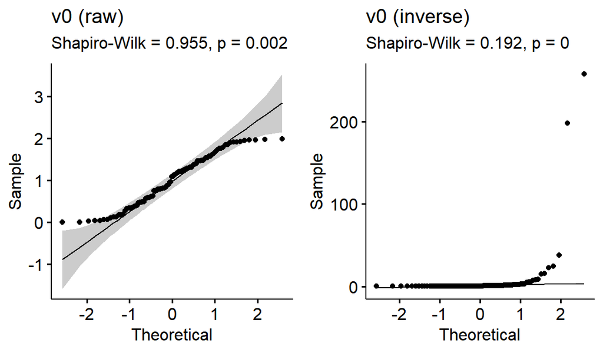

```r
v0 <- runif(100, min = 0, max = 2)

transf(v0, 'inverse')
```

So, this is all, I guess.